# Lecture 12: Fisher’s Linear Discriminant Analysis (FLDA) for 2-Class Problem

Zhaoxia Yu

Professor, Department of Statistics

2026-05-31

```r
knitr::opts_chunk$set(echo = TRUE)
library(tidyr) #the pipe (%>%) tool is extremely useful
library(MASS)
library(tidyverse)
```

## Outline

- Review PCA and introduction to LDA
- Fisher’s LDA for 2-class problem
- Examples

# Review PCA and introduction to LDA

## The Spectral Decomposition of A Covariance Matrix

- Let $\boldsymbol\Sigma_{p\times p}$ be the covariance matrix of $\mathbf X$.
- Spectral decomposition: $\boldsymbol \Sigma = \Gamma \Lambda \Gamma^T$
- $\Lambda$ is a diagonal matrix of eigenvalues:
  $$\lambda_1 \ge \lambda_2 \ge \cdots \lambda_p\ge 0$$
- $\Gamma=(\gamma_1, \cdots, \gamma_p)$, with the $i$th column being the eigenvector corresponding to $\lambda_i$.

## Maximizing Variance of $a^T X$

- First Principal Components is the linear combination with the maximum variance.
- The first PC is $Y_1 = \gamma_1^T X$. We have shown that
  $$\gamma_1=\underset{a^T a=1} {\mbox{arg max }} a^T \boldsymbol \Sigma a$$
- The second PC is $Y_2 = \gamma_2^T X$. We have shown that
  $$\gamma_2=\underset{a^T a=1, a^T\gamma_1=0} {\mbox{arg max }} a^T \boldsymbol \Sigma a$$
- The $i$th principal component is
  $$Y_i = \gamma_i^T X$$
  and

$$\gamma_i=\underset{a^T a=1, a^T\gamma_1=0, \cdots, a^T \gamma_{i-1}=0} {\mbox{arg max }} a^T \boldsymbol \Sigma a$$

## Example of PCA: Data

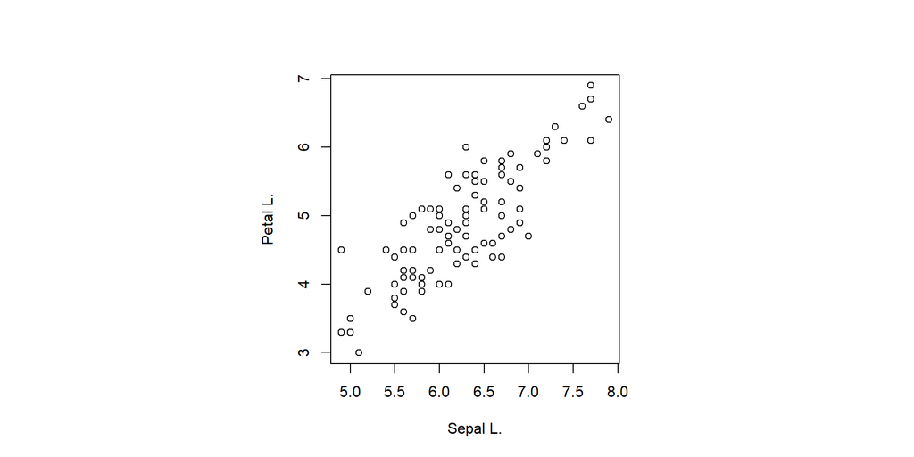

```r
sample1=iris3[,c(1,3),2]#Versicolor
sample2=iris3[,c(1,3),3]#Virginica
n1=nrow(sample1); n2=nrow(sample2)
xlab="SepalL"; ylab="PetalL"
pch=c("e","i"); col=c(2,3);
sample12=rbind(sample1, sample2)
par(pty="s")
plot(sample12)
```

- First PC

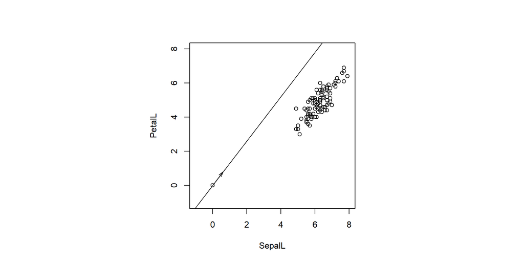

```r
pca.coeff=eigen(cov(sample12))$vector[,1]
proj.pca=(sample12%*%pca.coeff)%*%matrix(pca.coeff, 1,2)
par(pty="s")
plot(sample12, xlim=c(-1,8), ylim=c(-1,8), xlab=xlab, ylab=ylab)
points(0, 0)
arrows(0, 0, pca.coeff[1], pca.coeff[2], length = 0.1, angle=15, col="black")
abline(a=0, b=pca.coeff[2]/pca.coeff[1])
```

- Equivalently, we can use the line passing the center of the data.

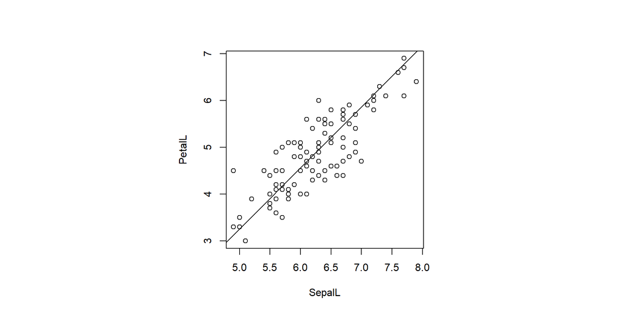

```r
par(pty="s")
plot(sample12, xlab=xlab, ylab=ylab)
abline(a=mean(sample12[,2] -  mean(sample12[,1]) *(pca.coeff[2]/pca.coeff[1]) ), b=pca.coeff[2]/pca.coeff[1])
```

## Project the data to the first PC

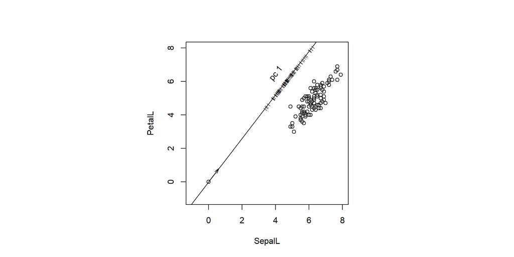

```r
proj.pca=(sample12%*%pca.coeff)%*%matrix(pca.coeff, 1,2)
par(pty="s")
plot(sample12, xlim=c(-1,8), ylim=c(-1,8), xlab=xlab, ylab=ylab)
points(0, 0)
arrows(0, 0, pca.coeff[1], pca.coeff[2], length = 0.1, angle=15, col="black")
abline(a=0, b=pca.coeff[2]/pca.coeff[1])
for(i in 1: (n1+n2)){
  text(x=proj.pca[i,1],y=proj.pca[i,2], labels="|", col="black",
       srt=atan(pca.coeff[2]/pca.coeff[1])*180/pi, cex=0.5)}
text(x=4, y=6.5, "pc 1", srt=50, col="black")
```

## Is PC 1 good for classification?

- The data includes 50 versicolor and 50 virginica samples.

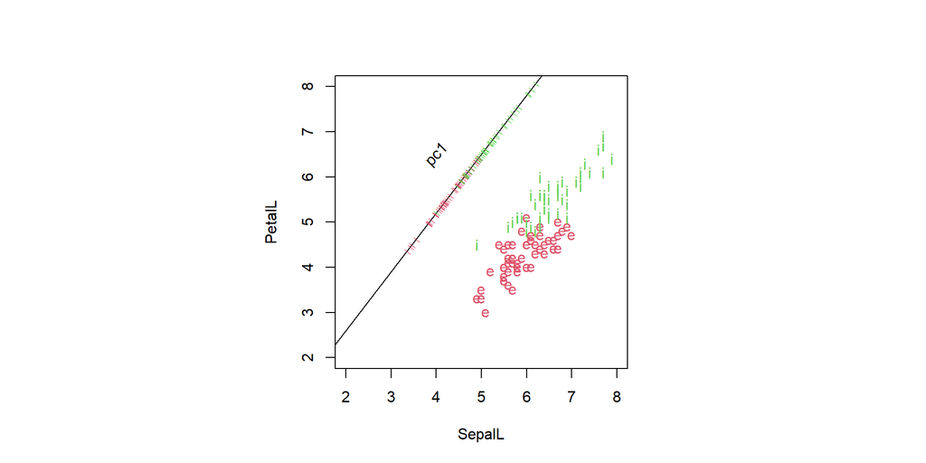

```r
proj.pca=(sample12%*%pca.coeff)%*%matrix(pca.coeff, 1,2)
par(pty="s")
plot(sample12, xlim=c(2,8), ylim=c(2,8), xlab=xlab, ylab=ylab, type="n")
points(sample1, pch=pch[1], col=col[1])
points(sample2, pch=pch[2], col=col[2])
points(0, 0)
arrows(0, 0, pca.coeff[1], pca.coeff[2], length = 0.1, angle=15, col="black")
abline(a=0, b=pca.coeff[2]/pca.coeff[1])
for(i in 1: (n1)){
  text(x=proj.pca[i,1],y=proj.pca[i,2], labels="|", col=col[1],
       srt=atan(pca.coeff[2]/pca.coeff[1])*180/pi, cex=0.5)}
for(i in (n1+1): (n1+n2)){
  text(x=proj.pca[i,1],y=proj.pca[i,2], labels="|", col=col[2],
       srt=atan(pca.coeff[2]/pca.coeff[1])*180/pi, cex=0.5)}
text(x=4, y=6.5, "pc1", srt=45, col="black")
```

- The difference between the two groups is obvious, but PCA is not designed for classification. Can we find a better linear combination for classification?

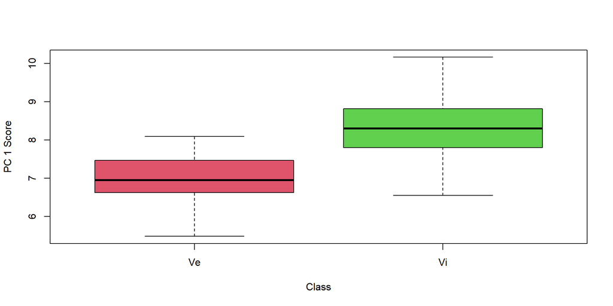

```r
boxplot(sample12%*%pca.coeff ~ c(rep("Ve", n1), rep("Vi", n2)), xlab="Class", ylab="PC 1 Score", col=col)
```

- PC 1: y=0.61SL + 0.79PL

```r
S.pooled=((n1-1)*cov(sample1)+(n2-1)*cov(sample2))/(n1+n2-2)
mean.diff=c( colMeans(sample1)-colMeans(sample2) )
data.center=c( (colMeans(sample1)+colMeans(sample2))/2 )
lda.coeff=solve(S.pooled)%*% mean.diff
#rescale it so that is has norm 1
lda.coeff=lda.coeff/sqrt(sum(lda.coeff^2))
pca.coeff
```

```
[1] 0.6090576 0.7931260
```

- Consider another linear combination: y=0.46SL - 0.89PL

```r
lda.coeff
```

```
               [,1]
Sepal L.  0.4610660
Petal L. -0.8873658
```

## Compare the two linear combinations

- How to define best separation?

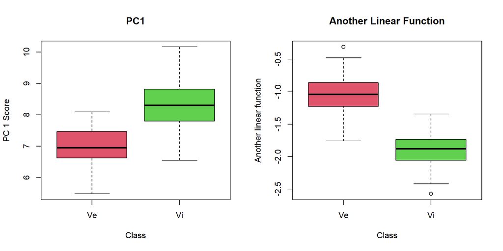

```r
par(mfrow=c(1,2))
boxplot(sample12%*%pca.coeff ~ c(rep("Ve", n1), rep("Vi", n2)), xlab="Class", ylab="PC 1 Score", col=col, main="PC1")
boxplot(sample12%*%lda.coeff ~ c(rep("Ve", n1), rep("Vi", n2)), xlab="Class", ylab="Another linear function", col=col, main="Another Linear Function")
```

# LDA

## What is Linear Discrminant Analysis

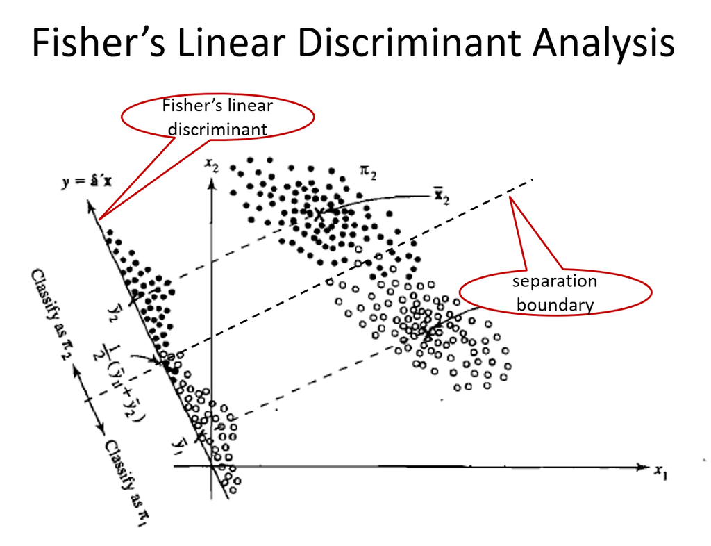

```r
knitr::include_graphics("img/FLDA.png")
```

## LDA

- Linear Discriminant Analysis (LDA) is a classification technique
- A linear discriminant is a **linear** function of the variables / features
- The goal of LDA is to find linear combinations of features that best separate the classes in the data.
- LDA sounds similar to PCA

## PCA vs LDA

- Both are linear, but
  - the first PC explains the most variance of the data
  - the first LD leads to the maximum separation
- Use of data labels
  - PCA does not use labels, unsupervised
  - LDA uses the labels, supervised

# FLDA

## LDA for two classes (FLDA)

- Fisher 1936 proposed a dichotomous discriminant analysis
- Fisher’s linear discriminant function is a **linear** function
- The linear function has the maximum ability to discriminant between samples
- Once we find the linear function, we
  - project the data on to it
  - find the boundary of different classes
  - allocate new observations

## FLDA: Assumptions

- Let’s consider a two-class classification problem with $n_1$ and $n_2$ observations in classes 1 and 2, respectively.
- Suppose we have two independent random samples
  - Sample 1: $X_{1j}\overset{iid}\sim (\mathbf \mu_1, \boldsymbol \Sigma)$, where $j=1, \cdots, n_1$
  - Sample 2: $X_{2j}\overset{iid}\sim (\mathbf \mu_2, \boldsymbol \Sigma)$, where $j=1, \cdots, n_2$
- Sample mean vectors:
  $$\bar {\mathbf X}_1=\frac{1}{n_1}\sum_{j=1}^{n_1}X_{1j},
  \bar {\mathbf X}_2=\frac{1}{n_2}\sum_{j=1}^{n_2}X_{2j}$$

## FLDA: The Goal

- How to define separability of a linear function?
- Consider a linear function with coefficients being denoted by a vector $a$.
  - $a^T\bar {\mathbf X}_1 \sim (a^T \mathbf \mu_1, \frac{1}{n_1}a^T\boldsymbol \Sigma a)$
  - $a^T\bar {\mathbf X}_2 \sim (a^T \mathbf \mu_2, \frac{1}{n_2}a^T\boldsymbol \Sigma a)$
- $a^T\bar {\mathbf X}_1 - a^T\bar {\mathbf X}_2$ measures the difference but the variation of this difference depends on the scale of $a$ and also the covariance structure.
- We need to “standardize” it by its standard error

## FLDA: Separability

- Recall that we have two independent random samples. Therefore,

$$(a^T\bar {\mathbf X}_1-a^T\bar {\mathbf X}_2) \sim \left(a^T \mathbf \mu_1- a^T \mathbf \mu_2, (\frac{1}{n_1} + \frac{1}{n_2})\boldsymbol a^T \Sigma a \right)$$

- The standardized version is

$$\frac{a^T\bar {\mathbf X}_1-a^T\bar {\mathbf X}_2}{\sqrt{(\frac{1}{n_1} + \frac{1}{n_2})a^T\boldsymbol \Sigma a}}$$

## FLDA: Separability

- The sign does not matter. So we consider the squared statistic
  $$\frac{(a^T\bar {\mathbf X}_1-a^T\bar {\mathbf X}_2)^2}{(\frac{1}{n_1} + \frac{1}{n_2})a^T \boldsymbol \Sigma a}
  \propto \frac{(a^T\bar {\mathbf X}_1 - a^T\bar {\mathbf X}_2)^2}{a^T \boldsymbol \Sigma a}$$
- Note that this is the squared t-statistic for testing $a^T\mathbf \mu_1=a^T\mathbf \mu_2$
- The Fisher LDA aims to find a linear combination of features $Y = a^TX$ that attains the maximum ratio.

## Maximizing Separability

- First, we write the ratio
  $$\begin{aligned}
  &\max \frac{(a^T\bar {\mathbf X}_1 - a^T\bar {\mathbf X}_2)^2}{a^T \boldsymbol \Sigma a}\\
  =& \max \frac{a^T(\bar {\mathbf X}_1 - \bar {\mathbf X}_2)(\bar {\mathbf X}_1 - \bar {\mathbf X}_2)^T a
  }{a^T \boldsymbol \Sigma a}\\
  \overset{\mbox{Let } b= \Sigma^{1/2} a} = &\max \frac{b^T \Sigma^{-1/2}(\bar {\mathbf X}_1 - \bar {\mathbf X}_2)(\bar {\mathbf X}_1 - \bar {\mathbf X}_2)^T\Sigma^{-1/2}b}{b^Tb}
  \end{aligned}$$

## Maximizing Separability

- The maximization problem is to maximize
  $$\frac{b^TA b}{b^Tb},$$
  where $A=\boldsymbol \Sigma^{-1/2}(\bar {\mathbf X}_1 - \bar {\mathbf X}_2)(\bar {\mathbf X}_1 - \bar {\mathbf X}_2)^T\Sigma^{-1/2}.$
- From the derivation of $PCA$, we understand that the maximum equals the largest eigenvalue of $A$.

## Maximizing Separability

- The rank of $A$ is 1, which means there is only one non-zero eigenvalue, which is
  $$(\bar {\mathbf X}_1 - \bar {\mathbf X}_2)^T\boldsymbol \Sigma^{-1}(\bar {\mathbf X}_1 - \bar {\mathbf X}_2)$$
- The maximum of $\frac{b^TA b}{b^Tb}$ is attained when $b$ is the first eigenvector of $A$. It can be verified that
  $$b=\boldsymbol \Sigma^{-1/2}(\bar {\mathbf X}_1 - \bar {\mathbf X}_2),$$

which implies that $a=\boldsymbol \Sigma^{-1}(\bar {\mathbf X}_1 - \bar {\mathbf X}_2)$.

- Therefore, the linear discriminant is a projection to the vector $a=\boldsymbol \Sigma^{-1}(\bar {\mathbf X}_1 - \bar {\mathbf X}_2)$

## Practical Issues

- Need to replace $\boldsymbol \Sigma$ by the pooled sample covariance matrix
  $$\mathbf{S}_p = \dfrac{(n_1-1)\mathbf{S}_1+(n_2-1)\mathbf{S}_2}{n_1+n_2-2}$$
  where $\mathbf S_1$ and $\mathbf S_2$ are the sample covariance matrices:

$$\begin{aligned}
\mathbf S_1=\frac{1}{n_1-1}\sum_{j=1}^{n_1}(X_{1j}-\bar {\mathbf X}_1)(X_{1j}-\bar {\mathbf X}_1)^T\\
\mathbf S_2=\frac{1}{n_2-1}\sum_{j=1}^{n_2}(X_{2j}-\bar {\mathbf X}_2)(X_{2j}-\bar {\mathbf X}_2)^T
\end{aligned}$$

## Allocate New Observations

- Fisher’s linear discriminant function
  $$f(x)=a^T x \mbox{ where } a=\mathbf S_p^{-1}(\bar {\mathbf X}_1 - \bar {\mathbf X}_2).$$
- Projected mid-point
  $$m=a^T \frac{\bar {\mathbf X}_1 + \bar {\mathbf X}_2}{2}=\frac{1}{2}\boldsymbol (\bar {\mathbf X}_1 - \bar {\mathbf X}_2)^T \mathbf S_p^{-1}(\bar {\mathbf X}_1 + \bar {\mathbf X}_2)$$
- Consider an observation $x_0$. We allocate it to
  - class 1 if $f(x_0)>m$
  - class 2 if $f(x_0)<m$

## The Linear Boundary

- The boundary $f(x)=m$ is linear
- Consider a two-class classification problem in $\mathbb R^2$, i.e., there are two features.
- The line that separates the two classes is $f(x)=m$, i.e.,
  $$a_1x_1 + a_2x_2=m$$
  or

$$x_2=\frac{m}{a_2}- \frac{a_1}{a_2}x_1$$

# FLDA as A Distance Approach

## FLDA as A Distance Approach

- FLDA replies on the sign of $f(x_0)-m$

$$\begin{aligned}
f(x_0)-m &= a^T (x_0 - \frac{\bar {\mathbf X}_1 + \bar {\mathbf X_2}}{2})\\
&=(\bar {\mathbf X}_1 - \bar {\mathbf X}_2)^T \mathbf S_p^{-1}(x_0 - \frac{\bar {\mathbf X}_1 + \bar {\mathbf X_2}}{2})\\
&=(\bar {\mathbf X}_1 - x_0 + x_0- \bar {\mathbf X}_2)^T \mathbf S_p^{-1}( \frac{x_0 - \bar {\mathbf X}_1 + x_0 - \bar {\mathbf X_2}}{2})\\
&=\frac{1}{2}[(x_0 - \bar {\mathbf X}_2)^T\mathbf S_p^{-1}(x_0 - \bar {\mathbf X}_2) -
(x_0 - \bar {\mathbf X}_1)^T\mathbf S_p^{-1}(x_0 - \bar {\mathbf X}_1)]\\
&= \frac{1}{2}[D_{S_p}^2(x_0, \bar {\mathbf X}_2) - D_{S_p}^2(x_0, \bar {\mathbf X}_1)]
\end{aligned}$$

## FLDA as A Distance Approach

- In the previous slide, we showed that
  $$f(x_0)-m=\frac{1}{2}[D_{S_p}^2(x_0, \bar {\mathbf X}_2) - D_{S_p}^2(x_0, \bar {\mathbf X}_1)]$$
  where $D_{S_p}^2(x_0, \bar {\mathbf X}_g)$ denotes the Mahalanobis distance between $x_0$ and $\bar {\mathbf X}_g$ for $g=1,2$.
- Therefore, $f(x_0)-m>0 \Leftrightarrow D_{S_p}(x_0, \bar {\mathbf X}_2) > D_{S_p}(x_0, \bar {\mathbf X}_1)$, we class $x_0$ to class 1.
- Similarly, we allocate $x_0$ to class 2 if $D_{S_p}(x_0, \bar {\mathbf X}_2) < D_{S_p}(x_0, \bar {\mathbf X}_1)$
- Thus, the FLDA is also a minimum distance method for classification.

# As A Maximum Likelihood Approach

## FLDA as A Maximum Likelihood Approach

- The likelihood function if $x_0$ is from $N(\mathbf \mu_1, \boldsymbol \Sigma)$
  $$L_1 \propto|\boldsymbol \Sigma|^{-1/2} exp\{-\frac{1}{2} (x_0-\mathbf \mu_1)^T \boldsymbol \Sigma^{-1} (x_0 -\mathbf \mu_1) \}$$
- The likelihood function if $x_0$ is from $N(\mathbf \mu_2, \boldsymbol \Sigma)$
  $$L_2 \propto|\boldsymbol \Sigma|^{-1/2} exp\{-\frac{1}{2} (x_0-\mathbf \mu_2)^T \boldsymbol \Sigma^{-1} (x_0 -\mathbf \mu_2) \}$$

## FLDA as A ML Approach

- The ratio is
  $$\begin{aligned}
  \frac{L_1}{L_2} &\overset{Data}=exp\{\frac{1}{2}[
  (x_0-\bar {\mathbf X}_2)^T \boldsymbol \Sigma^{-1} (x_0 -\bar {\mathbf X}_2) - \\
  & (x_0-\bar {\mathbf X}_1)^T \boldsymbol \Sigma^{-1} (x_0 -\bar {\mathbf X}_1)
  ]\}\\
  &=exp\{\frac{1}{2} [D_{S_p}^2(x_0, \bar {\mathbf X}_2) - D_{S_p}^2(x_0, \bar {\mathbf X}_1)] \}
  \end{aligned}$$
- Note that
  $$\frac{L_1}{L_2}>1 \Leftrightarrow D_{S_p}^2(x_0, \bar {\mathbf X}_2) > D_{S_p}^2(x_0, \bar {\mathbf X}_1) \Leftrightarrow f(x_0)>m$$
- Therefore, FLDA is also a maximum likelihood approach

# Example: FLDA

## Iris Data: Two Species, Two Features

- The Data

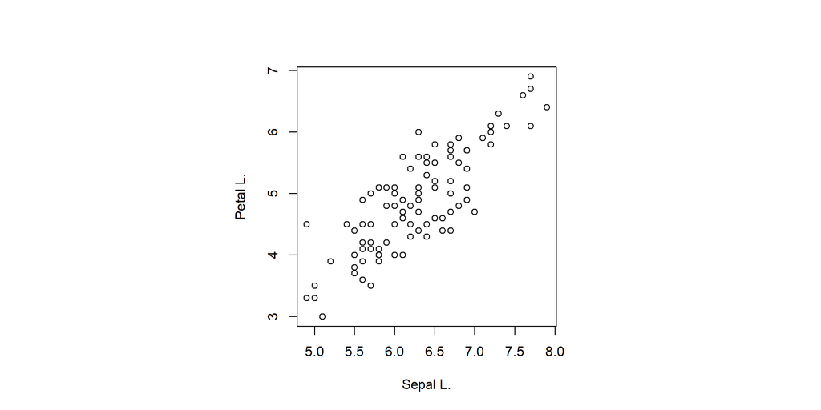

```r
sample1=iris3[,c(1,3),2]#Versicolor
sample2=iris3[,c(1,3),3]#Virginica
sample12=rbind(sample1, sample2)
par(pty="s")
plot(sample12)
```

## This is a Supervised Learning

- Two species: versicolor and virginica

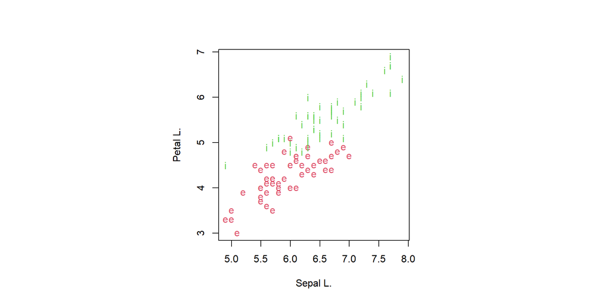

```r
pch=c("e","i"); col=c(2,3); xlab="SepalL"; ylab="PetalL"
par(pty="s")
plot(sample12,type="n")
points(sample1, col=col[1], pch=pch[1])
points(sample2, col=col[2], pch=pch[2])
```

## Sample Mean Vectors

- Versicolor

```r
colMeans(sample1)
```

```
Sepal L. Petal L.
   5.936    4.260
```

- Virginica

```r
colMeans(sample2)
```

```
Sepal L. Petal L.
   6.588    5.552
```

- Difference and average

```r
mean.diff=c( colMeans(sample1)-colMeans(sample2) )
data.center=c( (colMeans(sample1)+colMeans(sample2))/2 )
```

## Pooled Sample Covariance Matrix

```r
n1=dim(sample1)[1]
n2=dim(sample2)[1]
S.pooled=((n1-1)*cov(sample1)+(n2-1)*cov(sample2))/(n1+n2-2)
S.pooled
```

```
          Sepal L.  Petal L.
Sepal L. 0.3353878 0.2430939
Petal L. 0.2430939 0.2627020
```

## Compute The Linear Discrminant

- Compute $a=\boldsymbol \Sigma^{-1}(\bar {\mathbf X}_1 - \bar {\mathbf X}_2)$.

```r
lda.coeff=solve(S.pooled)%*% mean.diff
#rescale it so that is has norm 1
```

- Standardize $a$ such that $||a||=1$.

```r
lda.coeff=lda.coeff/sqrt(sum(lda.coeff^2))
lda.coeff
```

```
               [,1]
Sepal L.  0.4610660
Petal L. -0.8873658
```

## Allocate Observations

- Compute $m=a^T \frac{\bar {\mathbf X}_1 + \bar {\mathbf X}_2}{2}$

```r
m=c(t(lda.coeff)%*%data.center)
```

- Compute $f(x)$ for each observation (training data)

```r
proj.scalar=(sample12%*%lda.coeff)
```

## Classification Accuracy

```r
sum(proj.scalar[1:n1]>m)
```

```
[1] 47
```

```r
sum(proj.scalar[1:n1]>m)/n1
```

```
[1] 0.94
```

```r
sum(proj.scalar[-c(1:n2)]<m)
```

```
[1] 47
```

```r
sum(proj.scalar[-c(1:n2)]<m)/n2
```

```
[1] 0.94
```

```r
(sum(proj.scalar[1:n1]>m) + sum(proj.scalar[-c(1:n1)]<m)) /(n1+n2)
```

```
[1] 0.94
```

# Example: Visualization

## Visualize the LD Coefficients

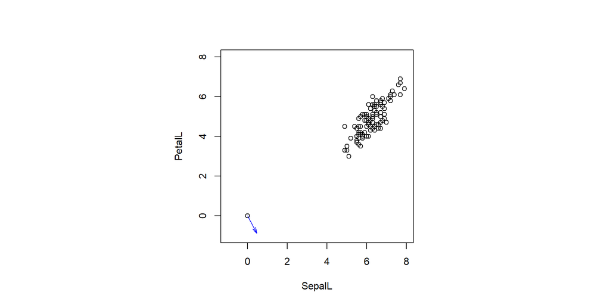

```r
par(pty="s")
plot(sample12, xlim=c(-1,8), ylim=c(-1,8), xlab=xlab, ylab=ylab)
points(0, 0)
arrows(0, 0, lda.coeff[1], lda.coeff[2], length = 0.1, angle=15, col="blue")
```

## The Projection

- We project the data matrix to the linear discriminant vector
  $$Porj_a(\mathbf X)=(\mathbf X a) a^T$$

```r
m=c(t(lda.coeff)%*%data.center)
proj=(sample12%*%lda.coeff)%*%matrix(lda.coeff, 1,2)
#note: proj includes the direction of the projected values
#note: (sample12%*%lda.coeff) gives the scalar values
```

## Visualize the Projection

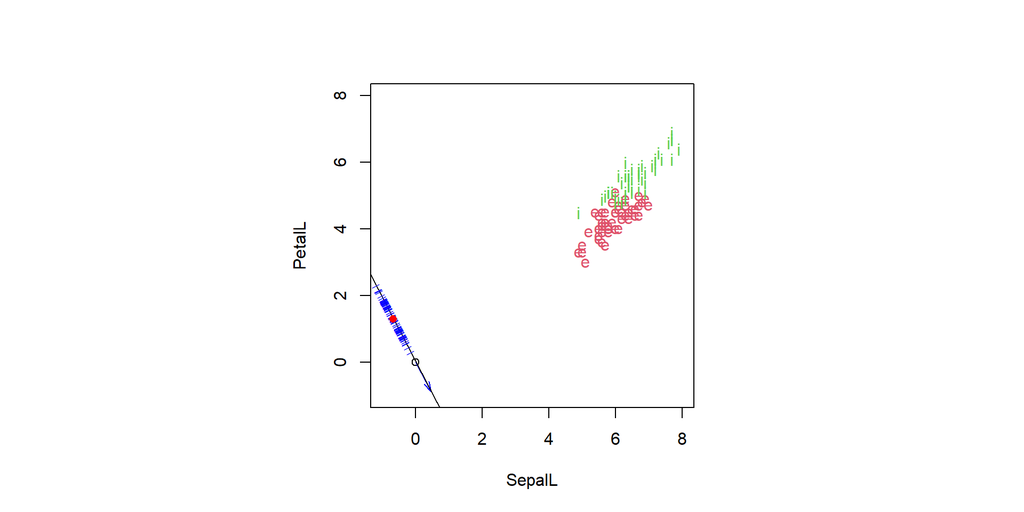

```r
par(pty="s")
plot(sample12, xlim=c(-1,8), ylim=c(-1,8), xlab=xlab, ylab=ylab, type="n")
points(sample1, pch=pch[1], col=col[1])
points(sample2, pch=pch[2], col=col[2])
points(0,0)
arrows(0, 0, lda.coeff[1], lda.coeff[2], length = 0.1, angle=15, col="blue")
abline(a=0, b=lda.coeff[2]/lda.coeff[1])
for(i in 1: (n1+n2))
  text(x=proj[i,1],y=proj[i,2], labels="|", col="blue", srt=atan(lda.coeff[2]/lda.coeff[1])*180/pi, cex=0.5)
#the center the projected data
points(m*lda.coeff[1], m*lda.coeff[2], pch=16, col="red")
```

## Find the Boundary

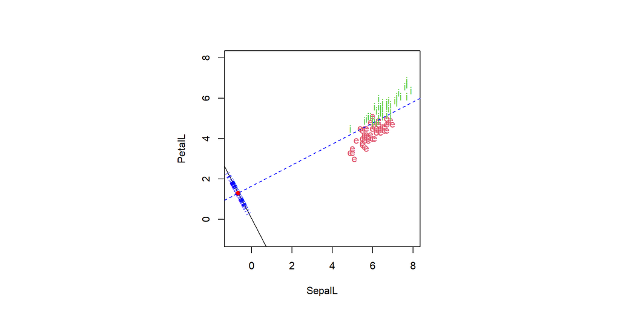

```r
par(pty="s")
plot(sample12, xlim=c(-1,8), ylim=c(-1,8), xlab=xlab, ylab=ylab, type="n")
points(sample1, pch=pch[1], col=col[1])
points(sample2, pch=pch[2], col=col[2])

abline(a=0, b=lda.coeff[2]/lda.coeff[1])
for(i in 1: (n1+n2))
  text(x=proj[i,1],y=proj[i,2], labels="|", col="blue", srt=atan(lda.coeff[2]/lda.coeff[1])*180/pi, cex=0.5)
points(m*lda.coeff[1], m*lda.coeff[2], pch=16, col="red")
abline(a=m/lda.coeff[2], b=-lda.coeff[1]/lda.coeff[2], col="blue", lty=2)
```

## Visualize the Allocations

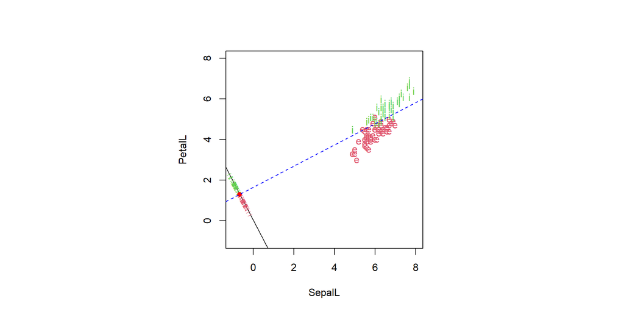

```r
proj.scalar=(sample12%*%lda.coeff)
par(pty="s")
plot(sample12, xlim=c(-1,8), ylim=c(-1,8), xlab=xlab, ylab=ylab, type="n")
points(sample1, pch=pch[1], col=col[1])
points(sample2, pch=pch[2], col=col[2])

abline(a=0, b=lda.coeff[2]/lda.coeff[1])
for(i in 1: (n1+n2)){
  if(proj.scalar[i]>m)
    text(x=proj[i,1],y=proj[i,2], labels="|", col=col[1],
         srt=atan(lda.coeff[2]/lda.coeff[1])*180/pi, cex=0.5)
  if(proj.scalar[i]<m)
    text(x=proj[i,1],y=proj[i,2], labels="|", col=col[2],
         srt=atan(lda.coeff[2]/lda.coeff[1])*180/pi, cex=0.5)
}
points(m*lda.coeff[1], m*lda.coeff[2], pch=16, col="red")
abline(a=m/lda.coeff[2], b=-lda.coeff[1]/lda.coeff[2], col="blue", lty=2)
```

# Example: PCA vs LDA

## PCA and LDA: Linear Combinations

- Although both are linear combinations, the goals are quite different
- LDA vs the 1st PC:
  - LDA: $a=\mathbf S_p^{-1}(\bar {\mathbf X}_1 - \bar {\mathbf X}_2)$
  - First PC: $a=\gamma_1$, the first eigenvector of $\boldsymbol \Sigma$.
- In the Iris two-class two-feature example, the coefficients are

```r
lda.coeff
```

```
               [,1]
Sepal L.  0.4610660
Petal L. -0.8873658
```

```r
pca.coeff=eigen(cov(sample12))$vector[,1]
pca.coeff
```

```
[1] 0.6090576 0.7931260
```

## PCA and LDA: Linear Combinations

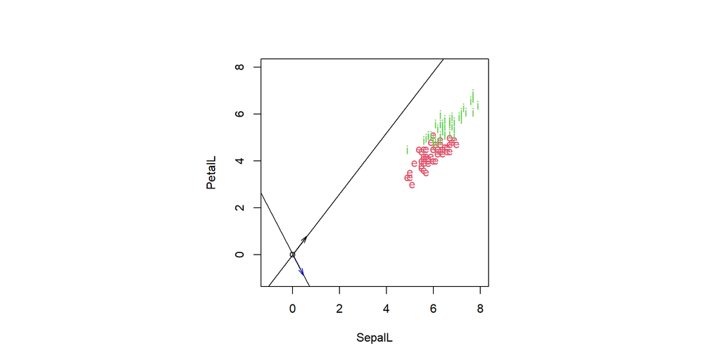

```r
proj.pca=(sample12%*%pca.coeff)%*%matrix(pca.coeff, 1,2)
par(pty="s")
plot(sample12, xlim=c(-1,8), ylim=c(-1,8), xlab=xlab, ylab=ylab, type="n")
points(sample1, pch=pch[1], col=col[1])
points(sample2, pch=pch[2], col=col[2])
points(0, 0)
arrows(0, 0, lda.coeff[1], lda.coeff[2], length = 0.1, angle=15, col="blue")
abline(a=0, b=lda.coeff[2]/lda.coeff[1])
arrows(0, 0, pca.coeff[1], pca.coeff[2], length = 0.1, angle=15, col="black")
abline(a=0, b=pca.coeff[2]/pca.coeff[1])
```

## PCA and LDA: Projections

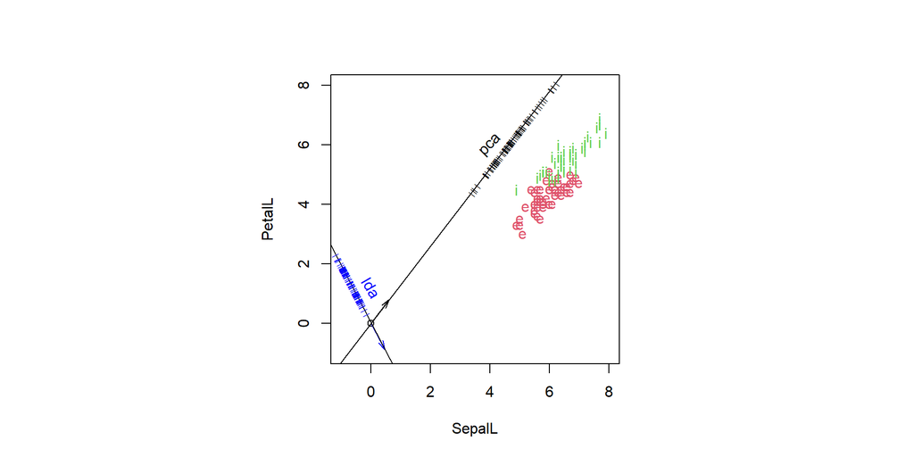

```r
proj.pca=(sample12%*%pca.coeff)%*%matrix(pca.coeff, 1,2)
par(pty="s")
plot(sample12, xlim=c(-1,8), ylim=c(-1,8), xlab=xlab, ylab=ylab, type="n")
points(sample1, pch=pch[1], col=col[1])
points(sample2, pch=pch[2], col=col[2])
points(0, 0)
arrows(0, 0, lda.coeff[1], lda.coeff[2], length = 0.1, angle=15, col="blue")
abline(a=0, b=lda.coeff[2]/lda.coeff[1])
arrows(0, 0, pca.coeff[1], pca.coeff[2], length = 0.1, angle=15, col="black")
abline(a=0, b=pca.coeff[2]/pca.coeff[1])
for(i in 1: (n1+n2)){
  text(x=proj[i,1],y=proj[i,2], labels="|", col="blue",
       srt=atan(lda.coeff[2]/lda.coeff[1])*180/pi, cex=0.5)
  text(x=proj.pca[i,1],y=proj.pca[i,2], labels="|", col="black",
       srt=atan(pca.coeff[2]/pca.coeff[1])*180/pi, cex=0.5)}
text(x=0, y=1.2, "lda", srt=-60, col="blue")
text(x=4, y=6, "pca", srt=45, col="black")
```

# LDA in R

## Use the “lda” function in R

```r
library(MASS)
mydata12=data.frame(G=rep(1:2, each=50),
                    x1=c(sample1[,1], sample2[,1]),
                    x2=c(sample1[,2], sample2[,2]))
obj <- lda(G ~ x1 + x2, data=mydata12)
obj
```

```
Call:
lda(G ~ x1 + x2, data = mydata12)

Prior probabilities of groups:
  1   2
0.5 0.5

Group means:
     x1    x2
1 5.936 4.260
2 6.588 5.552

Coefficients of linear discriminants:
         LD1
x1 -1.637937
x2  3.152368
```

## Plot an “lda” Object

```r
plot(obj)
```

```r
#tmp=as.matrix(mydata12[,2:3])%*% obj$scaling-mean(as.matrix(mydata12[,2:3])%*% obj$scaling)
#plot(tmp, predict(obj)$x)
#plot(m-proj.scalar, predict(obj)$x)
```

[figure not shown]

# Example: Four Features

## Iris Data: Two Species, Four Features

- We will use versicolor and virginica samples
- All the four features will be used in LDA

## Compute LDA

```r
sample1=iris3[,,2]#Versicolor
sample2=iris3[,,3]#Virginica
sample12=rbind(sample1, sample2)
n1=dim(sample1)[1]
n2=dim(sample2)[1]
mean.diff=c( colMeans(sample1)-colMeans(sample2) )
data.center=c( (colMeans(sample1)+colMeans(sample2))/2 )
S.pooled=((n1-1)*cov(sample1)+(n2-1)*cov(sample2))/(n1+n2-2)
lda.coeff=solve(S.pooled)%*% mean.diff
#rescale it so that is has norm 1
lda.coeff=lda.coeff/sqrt(sum(lda.coeff^2))
lda.coeff
```

```
               [,1]
Sepal L.  0.2268500
Sepal W.  0.3558499
Petal L. -0.4446115
Petal W. -0.7900826
```

## Classificatino Accuracy

```r
m=c(t(lda.coeff)%*%data.center)
proj.scalar=(sample12%*%lda.coeff)
sum(proj.scalar[1:n1]>m)
```

```
[1] 48
```

```r
sum(proj.scalar[1:n1]>m)/n1
```

```
[1] 0.96
```

```r
sum(proj.scalar[-c(1:n2)]<m)
```

```
[1] 49
```

```r
sum(proj.scalar[-c(1:n2)]<m)/n2
```

```
[1] 0.98
```

```r
(sum(proj.scalar[1:n1]>m) + sum(proj.scalar[-c(1:n1)]<m)) /(n1+n2)
```

```
[1] 0.97
```

## Use R to conduct LDA

```r
mydata12=data.frame(G=rep(1:2, each=50),
                    x1=sample12[,1], x2=sample12[,2],
                    x3=sample12[,3], x4=sample12[,4])
obj <- lda(G ~ x1 + x2 + x3 + x4, data=mydata12)
obj
```

```
Call:
lda(G ~ x1 + x2 + x3 + x4, data = mydata12)

Prior probabilities of groups:
  1   2
0.5 0.5

Group means:
     x1    x2    x3    x4
1 5.936 2.770 4.260 1.326
2 6.588 2.974 5.552 2.026

Coefficients of linear discriminants:
          LD1
x1 -0.9431178
x2 -1.4794287
x3  1.8484510
x4  3.2847304
```

## Visualize the lda object from R

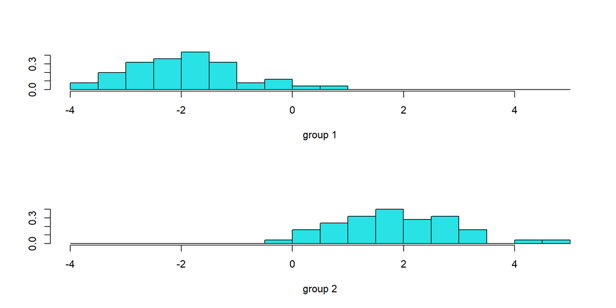

```r
plot(obj)
```

# PCA vs LDA: mathematical difference

- Both optimize (maximize) a ratio of two quadratic forms, but the numerator and denominator are different.
- PCA: $\frac{a^T \mathbf T a}{a^T a}$
- LDA basically maximized
  $$\frac{a^T \mathbf B a
  }{a^T \mathbf W a}$$